**City College of San Francisco**

MATH 108 - Foundations of Data Science

# Lecture 15: Sampling

Associated Textbook Sections: [10.0, 10.1, 10.2, 10.3](https://inferentialthinking.com/chapters/10/Sampling_and_Empirical_Distributions.html)

## Set Up the Notebook

```python
from datascience import *
import numpy as np
%matplotlib inline
import matplotlib.pyplot as plots
plots.style.use('fivethirtyeight')
```

# Table of Contents

## Sampling

### Random Samples

- Deterministic sample: Sampling scheme doesn't involve chance
- Random sample:
  - Before the sample is drawn, you have to know the selection probability of every group of people in the population
  - Not all individuals / groups have to have equal chance of being selected

### Demo: Random Sampling

Load the `united.csv` flight data containing information on United flights leaving SFO in 2015.

```python
united = Table.read_table('united.csv')
united = united.with_column('Row', np.arange(united.num_rows)).move_to_start('Row')
united
```

| Row | Date | Flight Number | Destination | Delay |
| --- | --- | --- | --- | --- |
| 0 | 6/1/15 | 73 | HNL | 257 |
| 1 | 6/1/15 | 217 | EWR | 28 |
| 2 | 6/1/15 | 237 | STL | -3 |
| 3 | 6/1/15 | 250 | SAN | 0 |
| 4 | 6/1/15 | 267 | PHL | 64 |
| 5 | 6/1/15 | 273 | SEA | -6 |
| 6 | 6/1/15 | 278 | SEA | -8 |
| 7 | 6/1/15 | 292 | EWR | 12 |
| 8 | 6/1/15 | 300 | HNL | 20 |
| 9 | 6/1/15 | 317 | IND | -10 |

... (13815 rows omitted)

Demonstrate how to use the `take` method to systematically sample the data.

```python
united.take(np.arange(0, united.num_rows, 1000))
```

| Row | Date | Flight Number | Destination | Delay |
| --- | --- | --- | --- | --- |
| 0 | 6/1/15 | 73 | HNL | 257 |
| 1000 | 6/7/15 | 1692 | EWR | 7 |
| 2000 | 6/14/15 | 824 | JFK | -1 |
| 3000 | 6/21/15 | 217 | EWR | 5 |
| 4000 | 6/27/15 | 1401 | SAN | -4 |
| 5000 | 7/4/15 | 1614 | LAS | -2 |
| 6000 | 7/11/15 | 401 | CLE | 4 |
| 7000 | 7/17/15 | 1645 | IAD | 0 |
| 8000 | 7/24/15 | 624 | ORD | 61 |
| 9000 | 7/30/15 | 1728 | ORD | 209 |

... (4 rows omitted)

```python
united.take(make_array(391, 6473, 10401))
```

| Row | Date | Flight Number | Destination | Delay |
| --- | --- | --- | --- | --- |
| 391 | 6/3/15 | 1273 | OGG | -6 |
| 6473 | 7/14/15 | 898 | JFK | -4 |
| 10401 | 8/8/15 | 1907 | IAD | 31 |

Use `np.random.choice` introduce an element of chance into the sampling process.

```python
np.random.choice?
```

```python
start = np.random.choice(1000)
united.take(np.arange(start, united.num_rows, 1000))
```

| Row | Date | Flight Number | Destination | Delay |
| --- | --- | --- | --- | --- |
| 676 | 6/5/15 | 1118 | EWR | 47 |
| 1676 | 6/12/15 | 361 | LIH | -6 |
| 2676 | 6/18/15 | 1670 | HNL | 8 |
| 3676 | 6/25/15 | 1073 | BOS | 44 |
| 4676 | 7/2/15 | 444 | BOS | -5 |
| 5676 | 7/9/15 | 478 | LAX | 83 |
| 6676 | 7/15/15 | 1606 | ORD | 16 |
| 7676 | 7/22/15 | 611 | SEA | -3 |
| 8676 | 7/28/15 | 1721 | KOA | 18 |
| 9676 | 8/4/15 | 650 | AUS | 27 |

... (4 rows omitted)

```python
np.random.choice(make_array('dog', 'cat', 'rabbit'))
```

```
'dog'
```

```python
np.random.choice(united.num_rows)
```

```
7696
```

### Sample of Convenience

- Example: sample consists of whoever walks by
- Just because you think you're sampling "randomly", doesn't mean you have a random sample.
- If you can't figure out the following ahead of time, then you don't have a random sample
  - what's the population
  - what's the chance of selection, for each group in the population

## Distrubtions

### Probability Distribution

- Random quantity with various possible values
- Probability Distribution:
  - All the possible values of the quantity
  - The probability of each of those values
- If you can do the math, you can work out the probability distribution without ever simulating it
- But... simulation is often easier!

### Empirical Distribution

- Empirical: based on observations
- Observations can be from repetitions of an experiment
- Empirical Distribution:
  - All observed values
  - The proportion of times each value appears

### Demo: Distributions

Create a table with the face numbers of a six-sided die. Use that table with the `sample` method to simulate randomly rolling a die. Visualize the empirical distribution.

```python
die = Table().with_column('Face', np.arange(1, 7))
die
```

| Face |
| --- |
| 1 |
| 2 |
| 3 |
| 4 |
| 5 |
| 6 |

```python
die.sample(10)
```

| Face |
| --- |
| 6 |
| 6 |
| 6 |
| 3 |
| 2 |
| 5 |
| 4 |
| 5 |
| 1 |
| 5 |

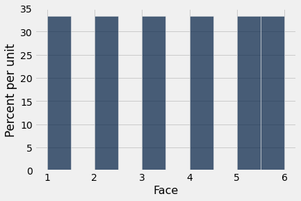

```python
die.hist()
```

Update the bins and randomly sample for a few different sample sizes.

```python
roll_bins = np.arange(0.5, 6.6, 1)
```

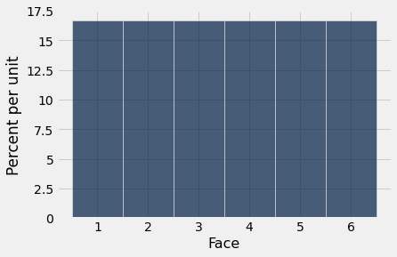

```python
die.hist(bins = roll_bins) # prob dist for rolling a die
```

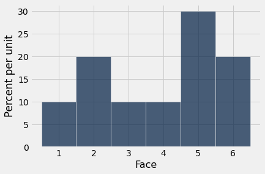

```python
die.sample(10).hist(bins = roll_bins)
```

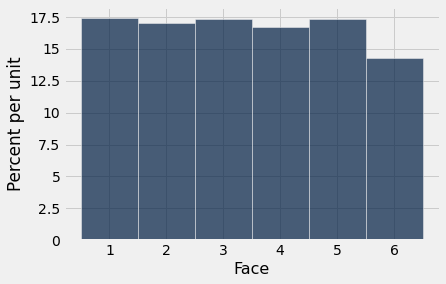

```python
die.sample(1000).hist(bins = roll_bins)
```

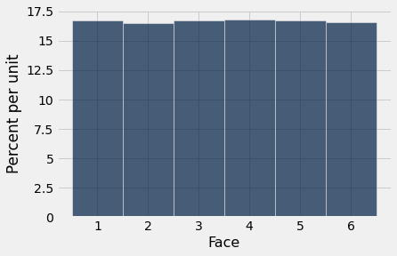

```python
die.sample(100000).hist(bins = roll_bins)
```

## Large Random Samples

### Law of Averages / Law of Large Numbers

- If a chance experiment is repeated many times, independently and under the same conditions, then the proportion of times that an event occurs gets closer to the theoretical probability of the event
- As you increase the number of rolls of a six-sided die, the proportion of times you see the face with five spots gets closer to 1/6

### Empirical Distribution of a Sample

If the sample size is large, then the empirical distribution of a uniform random sample resembles the distribution of the population, with high probability.

### Demo: Large Random Samples

Visualize the distribution of flight delays in the `united` data.

```python
united
```

| Row | Date | Flight Number | Destination | Delay |
| --- | --- | --- | --- | --- |
| 0 | 6/1/15 | 73 | HNL | 257 |
| 1 | 6/1/15 | 217 | EWR | 28 |
| 2 | 6/1/15 | 237 | STL | -3 |
| 3 | 6/1/15 | 250 | SAN | 0 |
| 4 | 6/1/15 | 267 | PHL | 64 |
| 5 | 6/1/15 | 273 | SEA | -6 |
| 6 | 6/1/15 | 278 | SEA | -8 |
| 7 | 6/1/15 | 292 | EWR | 12 |
| 8 | 6/1/15 | 300 | HNL | 20 |
| 9 | 6/1/15 | 317 | IND | -10 |

... (13815 rows omitted)

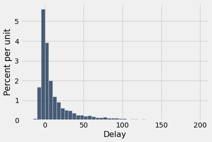

```python
united_bins = np.arange(-20, 201, 5)
united.hist('Delay', bins = united_bins)
```

Perform several calculations on the delay values such as min, max, average, etc.

```python
min(united.column('Delay'))
```

```
-16
```

```python
max(united.column('Delay'))
```

```
580
```

```python
np.average(united.column('Delay'))
```

```
16.658155515370705
```

```python
np.median(united.column('Delay'))
```

```
2.0
```

Randomly sample 10 and 1000 flights from the United data and visualize the distributions of the samples.

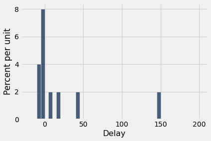

```python
united.sample(10).hist('Delay', bins = united_bins)
```

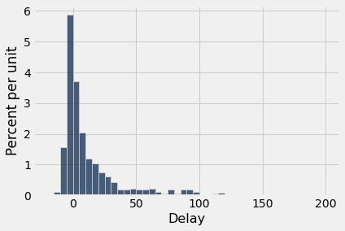

```python
united.sample(1000).hist('Delay', bins = united_bins)
```

## A Statistic

### Inference

- Statistical Inference: Making conclusions based on data in random samples
- Example: Use the data to guess the value of an unknown and fixed number by creating an estimate of the unknown quantity that depends on the random sample.

### Terminology

- Parameter: A number associated with the population
- Statistic: A number calculated from the sample
- A statistic can be used as an estimate of a parameter

### Demo: Simulating Statistics

Calculate the median parameter for the United flight delays and compare it to the median statistic associated with a random sample of 10 flights.

```python
np.median(united.column('Delay')) #parameter
```

```
2.0
```

```python
np.median(united.sample(10).column('Delay')) #statistic
```

```
9.0
```

```python
np.median(united.sample(1000).column('Delay')) #statistic
```

```
2.0
```

Define a function that randomly samples United flight data for an inputed sample size and returns the median Delay for that sample.

```python
def sample_median(size):
    return np.median(united.sample(size).column('Delay'))
```

```python
sample_median(1000)
```

```
2.0
```

Simulate randomly sampling 10 flights 1000 times and storing the sample delay medians for each iteration. Add the results to a table and visualize the sampling distribution.

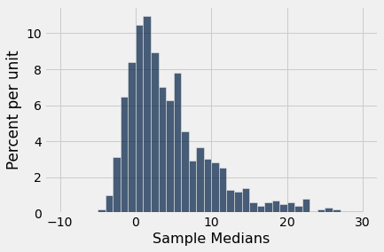

```python
sample_medians = make_array()

for _ in np.arange(1000):
    new_median = sample_median(10)
    sample_medians = np.append(sample_medians, new_median)

Table().with_column('Sample Medians', sample_medians).hist(bins=np.arange(-10,31))
```

Repeat the sample simulation except use a sample size of 1000, instead of 10.

```python
sample_medians = make_array()
```

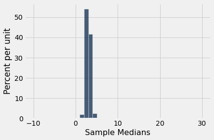

```python
for _ in np.arange(1000):
    new_median = sample_median(1000)
    sample_medians = np.append(sample_medians, new_median)

Table().with_column('Sample Medians', sample_medians).hist(bins=np.arange(-10,31))
```

### Probability Distribution of a Statistic

- Values of a statistic vary because random samples vary
- Sampling distribution (or probability distribution) of the statistic:
  - All possible values of the statistic,
  - and all the corresponding probabilities
  - Can be hard to calculate
    - Either have to do the math
    - Or have to generate all possible samples and calculate the statistic based on each sample

### Empirical Distribution of a Statistic

- Empirical distribution of the statistic:
  - Based on simulated values of the statistic
  - Consists of all the observed values of the statistic,
  - and the proportion of times each value appeared
- Good approximation to the probability distribution of the statistic if the number of repetitions in the simulation is large